# The Impact of Technology Access on Earnigs

Group 06

January 17, 2019

With a past of racial inequality in the southern states it would be interesting to examine how race/ethnicity is related to access to the internet and other technologies and how not having or having access could effect a persons earnings. This can be explored via the following research questions: In the state of Alabama, how to earnings vary by access to the internet/technology? Does the internet/technology premium vary by race and ethnicity?

# Step_1: System Setup

Before starting the program we need to clean the environment and import the library. The loaded librariesin the code are: 1. tidyverse 2. here 3. DataExplorer

# Step_2: Import Data

## Step_2.1: Import personal income Data

Here we will import the raw data of personal income (ss16pal) into the dataframe as “base”

```r
#load the persional data to variable Base
base <- read_csv(here('raw_data','ss16pal.csv'))%>%
  select(SERIALNO, #Serial Number to link House Hold and Personal data
         AGEP,  # Age: 0#99
         SEMP,  # Self-employment income past 12 months (signed)
         WAGP,  # Wages or salary income past 12 months
         HISP,  # Recoded detailed Hispanic origin
         NATIVITY,  # Nativity
         PERNP, # Total person's earnings
         RAC1P, # Recoded detailed race code
         RACAIAN, # American Indian and Alaska Native recode
         RACASN,  # Asian recode
         RACBLK,  # Black or African American recode
         RACNH, # Native Hawaiian recode
         RACWHT,  # White recode
         WAOB,  # World area of birth
         WKW)   #Weeks worked during past 12 months
```

## Step_2.2: Import household Data

We need to import the household level information (ss16hal) about technology access and merge the data into “base”

```r
#Link the house hould data
househould <- read_csv(here('raw_data','ss16hal.csv'))%>%
  select(SERIALNO, #Serial Number to link House Hold and Personal data
        ACCESS # Access to the Internet
  )
base <- base %>% left_join(househould) %>% select(-SERIALNO)
rm(househould)
```

# Step_3: First look of data structure.

```r
str(base)
```

```
## Classes 'spec_tbl_df', 'tbl_df', 'tbl' and 'data.frame': 47659 obs. of  15 variables:
##  $ AGEP    : chr  "84" "84" "78" "46" ...
##  $ SEMP    : chr  "0000000" "0000000" "0000000" "0000000" ...
##  $ WAGP    : chr  "0000000" "0000000" "0027300" "0065000" ...
##  $ HISP    : chr  "01" "01" "01" "01" ...
##  $ NATIVITY: num  1 1 1 1 1 1 1 1 1 1 ...
##  $ PERNP   : chr  "000000000" "000000000" "000027300" "000065000" ...
##  $ RAC1P   : num  1 1 1 1 1 1 1 1 1 1 ...
##  $ RACAIAN : num  0 0 0 0 0 0 0 0 0 0 ...
##  $ RACASN  : num  0 0 0 0 0 0 0 0 0 0 ...
##  $ RACBLK  : num  0 0 0 0 0 0 0 0 0 0 ...
##  $ RACNH   : num  0 0 0 0 0 0 0 0 0 0 ...
##  $ RACWHT  : num  1 1 1 1 1 1 1 1 1 1 ...
##  $ WAOB    : num  1 1 1 1 1 1 1 1 1 1 ...
##  $ WKW     : num  NA NA 1 1 NA NA NA NA NA 1 ...
##  $ ACCESS  : num  1 1 3 1 1 1 1 1 1 1 ...
```

# Step_4: Converting data

Convert the categorical data into factor type and numetical data into numeric type. The factorial data in this dataframe will keep its representative code instead of the category name to save the memory space.

```r
#conver the catagorical variable type
base <- base %>% mutate(HISP= as.factor(HISP),
                        RAC1P= as.factor(RAC1P),
                        RACAIAN = as.factor(RACAIAN),
                        RACASN = as.factor(RACASN),
                        RACBLK = as.factor(RACBLK),
                        RACNH = as.factor(RACNH),
                        RACWHT = as.factor(RACWHT),
                        WAOB = as.factor(WAOB),
                        WKW = as.factor(WKW),
                        ACCESS = as.factor(ACCESS)
                        )

#conver the numeric variable type
base <- base %>% mutate(AGEP = as.numeric(AGEP),
                        SEMP= as.numeric(SEMP),
                        WAGP= as.numeric(WAGP),
                        PERNP= as.numeric(PERNP)
                        )
```

Replace the factor level to the choices in the survery question for easy understanding.

```r
levels(base$ACCESS) <- convertCSV2Factor("ACCESS")
levels(base$HISP) <- convertCSV2Factor("HISP")
levels(base$RAC1P) <- convertCSV2Factor("RAC1P")
levels(base$RACAIAN) <- convertCSV2Factor("RACAIAN")
levels(base$RACASN) <- convertCSV2Factor("RACASN")
levels(base$RACBLK) <- convertCSV2Factor("RACBLK")
levels(base$RACNH) <- convertCSV2Factor("RACNH")
levels(base$RACWHT) <- convertCSV2Factor("RACWHT")
levels(base$WKW) <- convertCSV2Factor("WKW")
```

==================

# Step_5: Exploratory data analysis - EDA

## Step_5.1 EDA - Data Structure

```r
str(base)
```

```
## Classes 'tbl_df', 'tbl' and 'data.frame':    47659 obs. of  15 variables:
##  $ AGEP    : num  84 84 78 46 52 20 16 66 68 64 ...
##  $ SEMP    : num  0 0 0 0 0 0 0 0 0 0 ...
##  $ WAGP    : num  0 0 27300 65000 0 0 0 0 0 78000 ...
##  $ HISP    : Factor w/ 23 levels "Not Spanish/Hispanic/Latino",..: 1 1 1 1 1 1 1 1 1 1 ...
##  $ NATIVITY: num  1 1 1 1 1 1 1 1 1 1 ...
##  $ PERNP   : num  0 0 27300 65000 0 0 0 0 0 78000 ...
##  $ RAC1P   : Factor w/ 8 levels "White alone",..: 1 1 1 1 1 1 1 1 1 1 ...
##  $ RACAIAN : Factor w/ 2 levels "No","Yes": 1 1 1 1 1 1 1 1 1 1 ...
##  $ RACASN  : Factor w/ 2 levels "No","Yes": 1 1 1 1 1 1 1 1 1 1 ...
##  $ RACBLK  : Factor w/ 2 levels "No","Yes": 1 1 1 1 1 1 1 1 1 1 ...
##  $ RACNH   : Factor w/ 2 levels "No","Yes": 1 1 1 1 1 1 1 1 1 1 ...
##  $ RACWHT  : Factor w/ 2 levels "No","Yes": 2 2 2 2 2 2 2 2 2 2 ...
##  $ WAOB    : Factor w/ 8 levels "1","2","3","4",..: 1 1 1 1 1 1 1 1 1 1 ...
##  $ WKW     : Factor w/ 6 levels "50 to 52 weeks worked during past 12 months",..: NA NA 1 1 NA NA NA NA NA 1 ...
##  $ ACCESS  : Factor w/ 3 levels "Paid Access",..: 1 1 3 1 1 1 1 1 1 1 ...
```

## Step_5.2 EDA - Data Summary

```r
summary(base)
```

```
##       AGEP            SEMP             WAGP
##  Min.   : 0.00   Min.   : -6800   Min.   :     0
##  1st Qu.:22.00   1st Qu.:     0   1st Qu.:     0
##  Median :44.00   Median :     0   Median :  1800
##  Mean   :42.54   Mean   :  1278   Mean   : 21782
##  3rd Qu.:62.00   3rd Qu.:     0   3rd Qu.: 31200
##  Max.   :93.00   Max.   :266000   Max.   :356000
##                  NA's   :7597     NA's   :7597
##                                 HISP          NATIVITY
##  Not Spanish/Hispanic/Latino      :46252   Min.   :1.000
##  Mexican                          :  842   1st Qu.:1.000
##  Puerto Rican                     :  131   Median :1.000
##  Guatemalan                       :   96   Mean   :1.028
##  All Other Spanish/Hispanic/Latino:   88   3rd Qu.:1.000
##  Cuban                            :   48   Max.   :2.000
##  (Other)                          :  202
##      PERNP                                    RAC1P       RACAIAN
##  Min.   : -6800   White alone                    :34707   No :47142
##  1st Qu.:     0   Black or African American alone:10972   Yes:  517
##  Median :  4550   Two or More Races              :  734
##  Mean   : 23404   Asian alone                    :  558
##  3rd Qu.: 34000   Some Other Race alone          :  439
##  Max.   :622000   American Indian alone          :  185
##  NA's   :8185     (Other)                        :   64
##  RACASN      RACBLK      RACNH       RACWHT           WAOB
##  No :46928   No :36369   No :47646   No :12297   1      :45947
##  Yes:  731   Yes:11290   Yes:   13   Yes:35362   3      :  623
##                                                  4      :  553
##                                                  5      :  367
##                                                  2      :   62
##                                                  6      :   53
##                                                  (Other):   54
##                                               WKW
##  50 to 52 weeks worked during past 12 months    :16563
##  48 to 49 weeks worked during past 12 months    :  430
##  40 to 47 weeks worked during past 12 months    : 1116
##  27 to 39 weeks worked during past 12 months    : 1353
##  14 to 26 weeks worked during past 12 months    : 1166
##  less than 14 weeks worked during past 12 months: 1608
##  NA's                                           :25423
##          ACCESS
##  Paid Access:36959
##  Free Access: 1202
##  No Access  : 7186
##  NA's       : 2312
##
##
##
```

## Step_5.3 EDA - Age:

```r
base %>% select(AGEP) %>%  summary()
```

```
##       AGEP
##  Min.   : 0.00
##  1st Qu.:22.00
##  Median :44.00
##  Mean   :42.54
##  3rd Qu.:62.00
##  Max.   :93.00
```

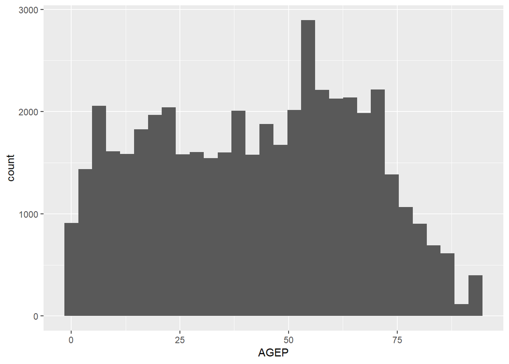

```r
base %>% ggplot(aes(AGEP)) + geom_histogram()
```

```r
base <- base %>%  filter(AGEP>=16 & AGEP <= 60)
base %>% select(AGEP) %>%  summary()
```

```
##       AGEP
##  Min.   :16.00
##  1st Qu.:27.00
##  Median :40.00
##  Mean   :39.06
##  3rd Qu.:51.00
##  Max.   :60.00
```

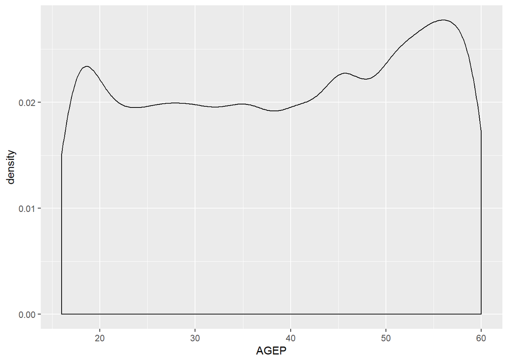

```r
base %>% ggplot(aes(AGEP)) + geom_density()
```

## Step_5.4 EDA - Labor:

We decided to exclude people:  
1. Worked less than 40 weeks in the last 12 months

```r
base <- base %>%  filter(as.integer(WKW)<4)
```

## Step_5.5 EDA - Wage:

Since the focus of our analysis is access to technology we can restrict the data by removing the rich and upper middle class (setting the max at the 3rd Quartile) because at a certain wage level we can conclude that technology becomes more about choice than access.

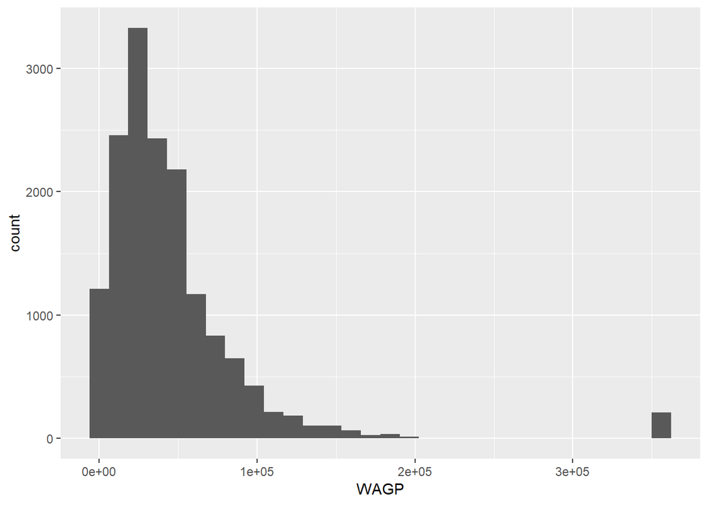

```r
base  %>% ggplot(aes(WAGP)) + geom_histogram()
```

```r
base <- base %>%  filter(WAGP<54000 & WAGP > 1000)
summary(base$WAGP)
```

```
##    Min. 1st Qu.  Median    Mean 3rd Qu.    Max.
##    1100   17000   27000   27829   40000   53000
```

Our earnings distributions after this considerations is:

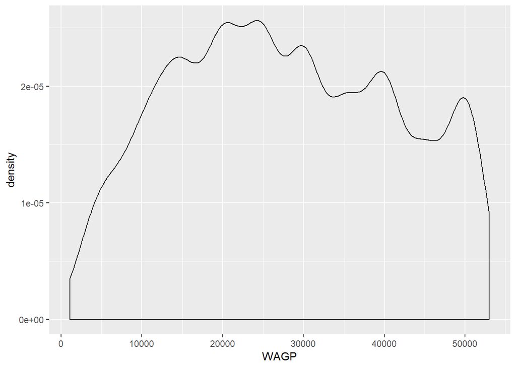

```r
base  %>% ggplot(aes(WAGP)) + geom_density()
```

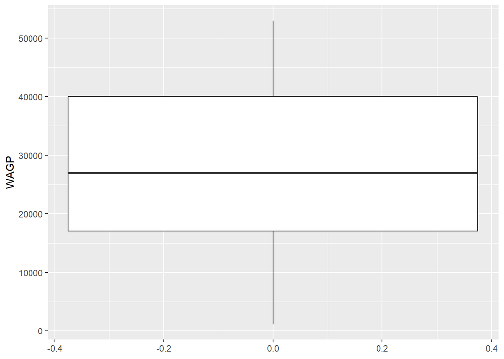

```r
base  %>% ggplot(aes(y=WAGP)) + geom_boxplot()
```

## Step_5.5 EDA - Missing data:

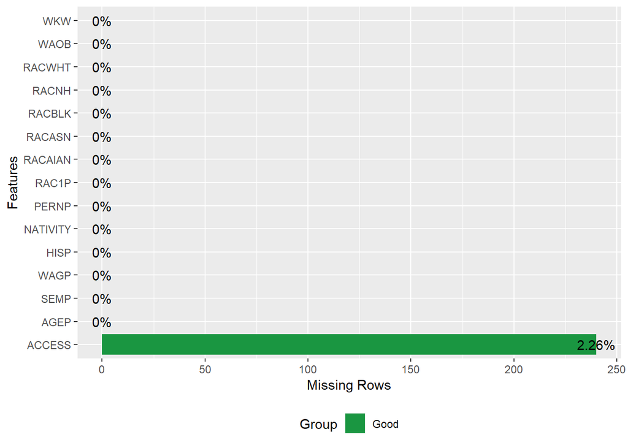

```r
plot_missing(base)
```

# Step_6: Exploratory data analysis after restrictions

```r
summary(base)
```

```
##       AGEP            SEMP               WAGP
##  Min.   :16.00   Min.   : -6800.0   Min.   : 1100
##  1st Qu.:28.00   1st Qu.:     0.0   1st Qu.:17000
##  Median :39.00   Median :     0.0   Median :27000
##  Mean   :38.99   Mean   :   365.6   Mean   :27829
##  3rd Qu.:50.00   3rd Qu.:     0.0   3rd Qu.:40000
##  Max.   :60.00   Max.   :266000.0   Max.   :53000
##
##                                 HISP          NATIVITY
##  Not Spanish/Hispanic/Latino      :10235   Min.   :1.000
##  Mexican                          :  225   1st Qu.:1.000
##  Puerto Rican                     :   34   Median :1.000
##  Guatemalan                       :   31   Mean   :1.039
##  All Other Spanish/Hispanic/Latino:   20   3rd Qu.:1.000
##  Cuban                            :    9   Max.   :2.000
##  (Other)                          :   53
##      PERNP                                    RAC1P      RACAIAN
##  Min.   : -3000   White alone                    :7596   No :10499
##  1st Qu.: 17000   Black or African American alone:2565   Yes:  108
##  Median : 27000   Some Other Race alone          : 135
##  Mean   : 28194   Two or More Races              : 133
##  3rd Qu.: 40000   Asian alone                    : 119
##  Max.   :316000   American Indian alone          :  45
##                   (Other)                        :  14
##  RACASN      RACBLK     RACNH       RACWHT          WAOB
##  No :10453   No :7994   No :10605   No :2892   1      :10096
##  Yes:  154   Yes:2613   Yes:    2   Yes:7715   3      :  259
##                                                4      :  134
##                                                5      :   78
##                                                6      :   14
##                                                2      :   12
##                                                (Other):   14
##                                               WKW               ACCESS
##  50 to 52 weeks worked during past 12 months    :9552   Paid Access:9075
##  48 to 49 weeks worked during past 12 months    : 270   Free Access: 273
##  40 to 47 weeks worked during past 12 months    : 785   No Access  :1019
##  27 to 39 weeks worked during past 12 months    :   0   NA's       : 240
##  14 to 26 weeks worked during past 12 months    :   0
##  less than 14 weeks worked during past 12 months:   0
##
```

==================

# Step_7: Examine access to the internet and its relation to earnings.

```r
base %>% select(ACCESS) %>% summary()
```

```
##          ACCESS
##  Paid Access:9075
##  Free Access: 273
##  No Access  :1019
##  NA's       : 240
```

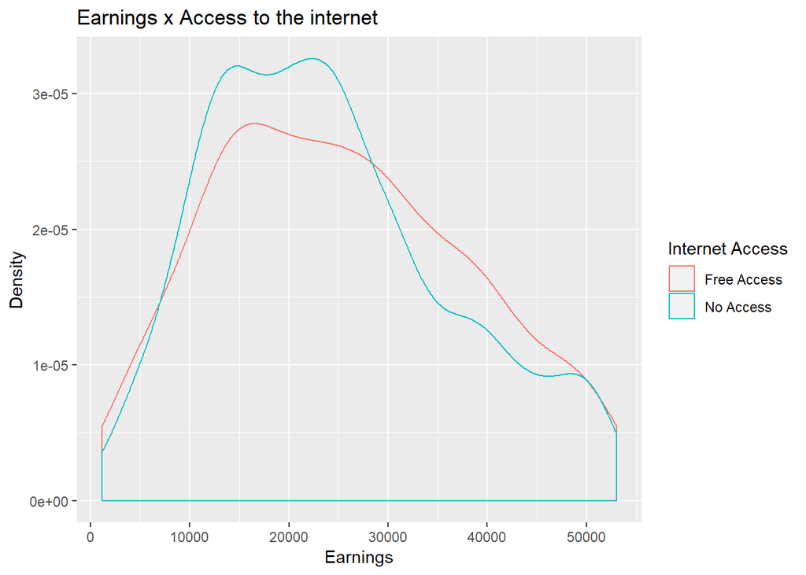

```r
base %>%  filter(!is.na(ACCESS) & ACCESS != "Paid Access") %>%
  ggplot(aes(WAGP,color=ACCESS)) + geom_density() +
  labs(title="Earnings x Access to the internet",
       x ="Earnings", y = "Density") +
  scale_color_discrete(name="Internet Access",
                      labels=c("Free Access", "No Access"))
```

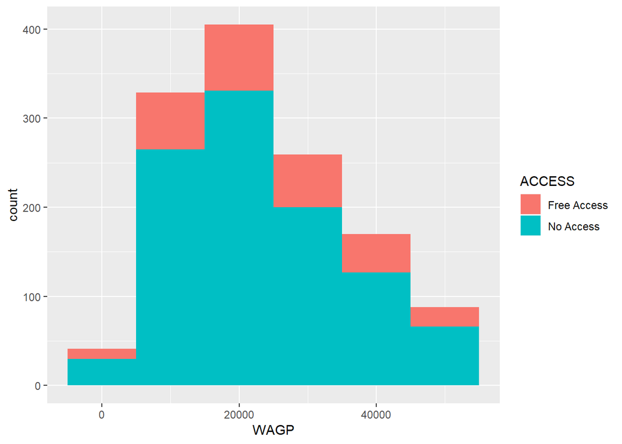

```r
base %>%  filter(!is.na(ACCESS) & ACCESS != "Paid Access") %>%
  ggplot() + geom_histogram(aes(x=WAGP,fill=ACCESS), binwidth = 10000)
```

```r
base %>%
  filter(!is.na(ACCESS) & ACCESS != "Paid Access") %>%
  group_by(ACCESS, RAC1P) %>%
  summarise (mean(WAGP),sd(WAGP),min(WAGP),max(WAGP), median(WAGP))
```

```
## # A tibble: 12 x 7
## # Groups:   ACCESS [?]
##    ACCESS RAC1P `mean(WAGP)` `sd(WAGP)` `min(WAGP)` `max(WAGP)`
##    <fct>  <fct>        <dbl>      <dbl>       <dbl>       <dbl>
##  1 Free ~ Whit~       25715.     12653.        1600       52000
##  2 Free ~ Blac~       25089.     12734.        2800       52000
##  3 Free ~ Amer~       18800        NaN        18800       18800
##  4 Free ~ Some~       31000      26870.       12000       50000
##  5 Free ~ Two ~       13667.      1528.       12000       15000
##  6 No Ac~ Whit~       26065.     12250.        1200       53000
##  7 No Ac~ Blac~       21593.     11429.        2000       52000
##  8 No Ac~ Amer~       17567.      9621.        6700       25000
##  9 No Ac~ Amer~       20000        NaN        20000       20000
## 10 No Ac~ Asia~       28500      12021.       20000       37000
## 11 No Ac~ Some~       20328.      9511.        9000       49000
## 12 No Ac~ Two ~       22550      13378.        5000       48000
## # ... with 1 more variable: `median(WAGP)` <dbl>
```

## Step_7.5 Race and access to the internet

```r
base %>% select(RAC1P) %>% summary()
```

```
##                              RAC1P
##  White alone                    :7596
##  Black or African American alone:2565
##  Some Other Race alone          : 135
##  Two or More Races              : 133
##  Asian alone                    : 119
##  American Indian alone          :  45
##  (Other)                        :  14
```

```r
base %>% filter(ACCESS=="No Access") %>% select(RAC1P) %>% summary() #person doesn't have ACCESS to Internet
```

```
##                              RAC1P
##  White alone                    :580
##  Black or African American alone:388
##  Some Other Race alone          : 29
##  Two or More Races              : 16
##  American Indian alone          :  3
##  Asian alone                    :  2
##  (Other)                        :  1
```

[figure not shown]

```r
base %>%  filter(!is.na(ACCESS) & ACCESS != "Paid Access") %>%
  ggplot() + geom_bar(aes(x = RAC1P, fill=ACCESS)) +
  coord_flip() +
  scale_x_discrete(labels = c('White', 'Black', 'Native American', "Multiple tribes", "Asian", 'Pacific Islander', 'Other', 'Two or more Races')) +
  theme(legend.position= c(0.62,0.85))
```

Building the model

```r
base_model <- base %>%
  filter(!is.na(ACCESS) & ACCESS != "Paid Access") %>%
  mutate(free_access = ACCESS == "Free Access",
         hispanic = HISP != "Not Spanish/Hispanic/Latino",
         black = RACBLK == "Yes"
         )

model_01 <- lm(WAGP ~ free_access, data = base_model)

model_01 %>% summary()
```

```
##
## Call:
## lm(formula = WAGP ~ free_access, data = base_model)
##
## Residuals:
##    Min     1Q Median     3Q    Max
## -23785  -9718  -1351   7882  28883
##
## Coefficients:
##                 Estimate Std. Error t value Pr(>|t|)
## (Intercept)      24117.5      382.4  63.076   <2e-16 ***
## free_accessTRUE   1267.9      831.8   1.524    0.128
## ---
## Signif. codes:  0 '***' 0.001 '**' 0.01 '*' 0.05 '.' 0.1 ' ' 1
##
## Residual standard error: 12210 on 1290 degrees of freedom
## Multiple R-squared:  0.001798,   Adjusted R-squared:  0.001024
## F-statistic: 2.323 on 1 and 1290 DF,  p-value: 0.1277
```

```r
model_02 <- lm(WAGP ~ free_access + hispanic + black, data = base_model)
model_02 %>% summary()
```

```
##
## Call:
## lm(formula = WAGP ~ free_access + hispanic + black, data = base_model)
##
## Residuals:
##    Min     1Q Median     3Q    Max
## -25075  -9100  -1675   7900  29900
##
## Coefficients:
##                 Estimate Std. Error t value Pr(>|t|)
## (Intercept)      25724.8      483.9  53.163  < 2e-16 ***
## free_accessTRUE    950.1      827.3   1.148   0.2510
## hispanicTRUE     -3740.7     1591.7  -2.350   0.0189 *
## blackTRUE        -3624.5      706.3  -5.132 3.32e-07 ***
## ---
## Signif. codes:  0 '***' 0.001 '**' 0.01 '*' 0.05 '.' 0.1 ' ' 1
##
## Residual standard error: 12080 on 1288 degrees of freedom
## Multiple R-squared:  0.02337,    Adjusted R-squared:  0.0211
## F-statistic: 10.27 on 3 and 1288 DF,  p-value: 1.099e-06
```

==================

# Notes on variable selection and restriction

Once we restricted the work related variables, we examined the earnings variable (WAGP). Since our analysis is focused on access to technology we removed the top quartile of earnings. This is because over a certain earnings rate technology acquisition is based more on choice than access. We also restricted the lower rate to $1000, we did this to limit the respondents who claimed to have worked for at least 50 weeks but reported $0 in earnings.